# Sentiment Analysis - Reddit Posts

## **SENTIMENT ANALYSIS OF REDDIT COMMENTS**

#### **Overview**

This notebook performs a comprehensive analysis of Reddit posts and comments related to ChatGPT. Users can expect to find the following key components:

1. **Data Collection** :
   - Importing and utilizing Reddit API credentials.
   - Importing necessary modules.
   - Calling the Reddit API to retrieve posts and comments data.
2. **Post & Comment Analysis**:
   - **Exploratory Data Analysis (EDA)**:
     - Extracting posts data and cleaning date formats.
   - **Visualizations**:
     - Analyzing the number of posts across different months.
     - Visualizing engagement metrics over time.
   - **Comments Analysis**:
     - Extracting and joining comments with their respective posts.
3. **Word Clouds**:
   - Generating word clouds to identify the most frequently used words:
     - Post title word cloud.
     - Comment word cloud.
     - Post title word cloud segmented by year.
4. **Sentiment Analysis**:
   - Testing sentiment analysis models.
   - Visualizing sentiment distribution for posts and comments using pie charts.
   - Creating a word cloud of common words categorized by sentiment (Positive, Negative, Neutral).
5. **Engagement Analysis**:
   - Analyzing engagement metrics by `link_flair_text`.
   - Evaluating engagement based on post sentiment.

This notebook aims to provide insights into user sentiment and engagement trends within the ChatGPT Reddit community, utilizing visualizations and word clouds to enhance understanding.

#### **1. Data Collection**

Import necessary libraries

```python
import pandas as pd  # For data manipulation and analysis

# Visualization libraries
from wordcloud import WordCloud  # For generating word clouds from text data
import matplotlib.pyplot as plt  # For plotting graphs and visualizations

# matplotlib inline Ensures that plots are displayed inline in Jupyter notebooks
%matplotlib inline

import seaborn as sns  # For enhanced data visualization with attractive themes

# Import PRAW (Python Reddit API Wrapper) for accessing data through the Reddit API
import praw
```

```python
from transformers import pipeline  # For using pre-trained models
import torch  # For handling tensor operations (PyTorch)
import tensorflow as tf  # For TensorFlow support, although not used in this example

# Load a pre-trained sentiment analysis model from the Hugging Face model hub
# The model used here is specifically trained for analyzing sentiment in tweets
sentiment_classifier = pipeline(model="finiteautomata/bertweet-base-sentiment-analysis", framework="pt")
```

```
c:\Users\Admin\Desktop\MINE\Projects\Reddit API\reddit\Lib\site-packages\transformers\tokenization_utils_base.py:1617: FutureWarning: `clean_up_tokenization_spaces` was not set. It will be set to `True` by default. This behavior will be deprecated in transformers v4.45, and will be then set to `Fals…
  warnings.warn(
```

Set up Reddit API credentials

```python
# This code initializes a PRAW instance for accessing the Reddit API, using your app's credentials

reddit = praw.Reddit(client_id = 'RaIOBg_72jFShXCADSBqDg',
                        client_secret = 'UpG0Q_rAWq9pkbzUui6Xb-ckF3vgUA',
                        redirect_url = 'https://venkatramoju01.github.io/MyWebsite/',
                        user_agent = 'Venkat_ramoju01'
            )
```

Let us write a function that fetches the top posts from specified subreddits using the Reddit API and converts them into a DataFrame.

```python
def get_top_posts(subreddit_list, limit, time_filter):
    # Initialize a Reddit instance using your app's credentials
    reddit = praw.Reddit(client_id = 'RaIOBg_72jFShXCADSBqDg',
                        client_secret = 'UpG0Q_rAWq9pkbzUui6Xb-ckF3vgUA',
                        redirect_url = 'https://venkatramoju01.github.io/MyWebsite/',
                        user_agent = 'Venkat_ramoju01'
            )

    # Fetch the top posts from the specified subreddit with given filters
    posts = reddit.subreddit(subreddit_list).top(time_filter, limit)

    #initialize empty list to convert into dataframe
    posts_df = []

    # Loop through the fetched posts and extract relevant information
    for post in posts:
        posts_df.append(
                        {
                            'post_id':post.id,
                            'subreddit': post.subreddit,
                            'created_utc': post.created_utc,
                            'selftext': post.selftext,
                            'post_url': post.url,
                            'post_title': post.title,
                            'link_flair_text': post.link_flair_text,
                            'score': post.score,
                            'num_comments': post.num_comments,
                            'upvote_ratio':post.upvote_ratio
                        }
                        )
    # Convert the list of posts into a pandas DataFrame and return it
    return pd.DataFrame(posts_df)

# Call the function to get top posts from the "ChatGPT" subreddit
posts_df=get_top_posts(subreddit_list="ChatGPT",limit=1000,time_filter="all")

# Save the DataFrame to a CSV file
posts_df.to_csv('Only_ChatGPT.csv',header=True,index=False)

# Display the first 10 rows of the DataFrame
posts_df.head(10)
```

|  | post_id | subreddit | created_utc | selftext | post_url | post_title | link_flair_text | score | num_comments | upvote_ratio |
| --- | --- | --- | --- | --- | --- | --- | --- | --- | --- | --- |
| 0 | 144lfc1 | ChatGPT | 1.686259e+09 |  | https://i.redd.it/81rl4zdt1v4b1.png | Turned ChatGPT into the ultimate bro | Funny | 67512 | 1147 | 0.96 |
| 1 | 1av10qh | ChatGPT | 1.708382e+09 |  | https://v.redd.it/td4k2r8idmjc1 | Will smith is wild for this | Funny | 56180 | 1706 | 0.86 |
| 2 | 13wfaqg | ChatGPT | 1.685518e+09 |  | https://www.reddit.com/gallery/13wfaqg | Photoshop AI Generative Fill was used for its ... | Other | 52080 | 1342 | 0.91 |
| 3 | 14gnv5b | ChatGPT | 1.687492e+09 | The guy typing out these responses for Bing mu... | https://www.reddit.com/gallery/14gnv5b | Bing ChatGPT too proud to admit mistake, doubl... | Gone Wild | 51386 | 2255 | 0.96 |
| 4 | 12cobqr | ChatGPT | 1.680709e+09 |  | https://i.redd.it/1g6v045f53sa1.png | Was curious if GPT-4 could recognize text art | Funny | 44584 | 662 | 0.98 |
| 5 | 12ed85v | ChatGPT | 1.680852e+09 |  | https://i.redd.it/vdd5irelzesa1.png | Unfiltered ChatGPT opinion about Reddit | Gone Wild | 40114 | 1518 | 0.96 |
| 6 | 198nse2 | ChatGPT | 1.705465e+09 |  | https://www.reddit.com/gallery/198nse2 | Make my hot dog hotter | Funny | 39844 | 1033 | 0.93 |
| 7 | 1fye6tb | ChatGPT | 1.728324e+09 |  | https://i.redd.it/yhhu3qiiidtd1.png | The human internet is dying. AI images taking ... | Gone Wild | 39376 | 2038 | 0.94 |
| 8 | 18z9a0j | ChatGPT | 1.704468e+09 |  | https://www.reddit.com/gallery/18z9a0j | Where ever could Waldo be? | Funny | 37781 | 963 | 0.97 |
| 9 | 1b4shrc | ChatGPT | 1.709398e+09 |  | https://www.reddit.com/gallery/1b4shrc | Give me a P! | Funny | 35152 | 715 | 0.93 |

#### **2. Post & Comment Analysis**

##### **Exploratory Data Analysis**

The `created_utc` date column is currently in UTC format. To facilitate our analysis, we should convert it into a datetime format.

```python
import datetime as dt
# Convert created data to datetime format
posts_df['created_utc']=posts_df['created_utc'].apply(lambda x: dt.datetime.fromtimestamp(x))
posts_df = posts_df.rename(columns={'created_utc': 'created_date'})
posts_df['created_year']=posts_df['created_date'].dt.year
posts_df.head(3)
```

|  | post_id | subreddit | created_date | selftext | post_url | post_title | link_flair_text | score | num_comments | upvote_ratio | created_year |
| --- | --- | --- | --- | --- | --- | --- | --- | --- | --- | --- | --- |
| 0 | 144lfc1 | ChatGPT | 2023-06-09 02:46:59 |  | https://i.redd.it/81rl4zdt1v4b1.png | Turned ChatGPT into the ultimate bro | Funny | 67512 | 1147 | 0.96 | 2023 |
| 1 | 1av10qh | ChatGPT | 2024-02-20 04:07:20 |  | https://v.redd.it/td4k2r8idmjc1 | Will smith is wild for this | Funny | 56180 | 1706 | 0.86 | 2024 |
| 2 | 13wfaqg | ChatGPT | 2023-05-31 12:55:04 |  | https://www.reddit.com/gallery/13wfaqg | Photoshop AI Generative Fill was used for its ... | Other | 52080 | 1342 | 0.91 | 2023 |

```python
posts_df.shape
```

[output not shown]

```python
posts_df.info()
```

```
<class 'pandas.core.frame.DataFrame'>
RangeIndex: 100 entries, 0 to 99
Data columns (total 11 columns):
 #   Column           Non-Null Count  Dtype
---  ------           --------------  -----
 0   post_id          100 non-null    object
 1   subreddit        100 non-null    object
 2   created_date     100 non-null    datetime64[ns]
 3   selftext         100 non-null    object
 4   post_url         100 non-null    object
 5   post_title       100 non-null    object
 6   link_flair_text  98 non-null     object
 7   score            100 non-null    int64
 8   num_comments     100 non-null    int64
 9   upvote_ratio     100 non-null    float64
 10  created_year     100 non-null    int32
dtypes: datetime64[ns](1), float64(1), int32(1), int64(2), object(6)
memory usage: 8.3+ KB
```

```python
posts_df['link_flair_text'].unique()
```

```
array(['Funny ', 'Other ', 'Gone Wild ', 'AI-Art',
       'Mona Lisa: Multiverse of Madness:illuminati:',
       'Educational Purpose Only ', None, 'Jailbreak', 'Fake ',
       'Serious replies only :closed-ai:', 'Prompt engineering ', 'Funny',
       'News 📰', 'The right way', 'Use cases '], dtype=object)
```

```python
#posts_df.describe(include='all')
posts_df.describe()
```

[output not shown]

```python
posts_df.num_comments.sum()
```

```
116107
```

##### **Visualizations**

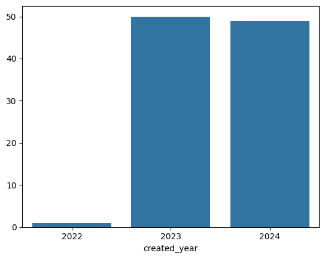

```python
# No. of posts each year
posts_per_year= posts_df.created_year.value_counts()
sns.barplot(x=posts_per_year.index,y=posts_per_year.values)
```

```python
# Extract year and month
posts_df['year_month'] = posts_df['created_date'].dt.to_period('M')
```

Let's analyze the number of posts across different months

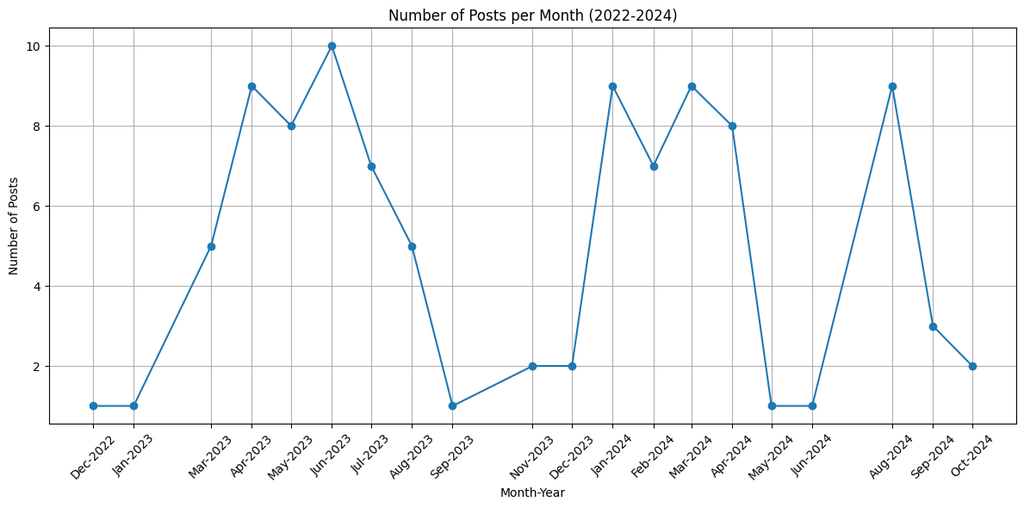

```python
# Count posts by year and month
post_counts = posts_df['year_month'].value_counts().sort_index()

# Convert the index to datetime for plotting
post_counts.index = post_counts.index.to_timestamp()

# Plotting
plt.figure(figsize=(12, 6))
plt.plot(post_counts.index, post_counts.values, marker='o')

# Formatting x-axis ticks to show "MMM-YYYY"
plt.xticks(post_counts.index, post_counts.index.strftime('%b-%Y'), rotation=45)

plt.title('Number of Posts per Month (2022-2024)')
plt.xlabel('Month-Year')
plt.ylabel('Number of Posts')
plt.grid()
plt.tight_layout()
plt.show()
```

Let us now analyze the engagement metrics (scores, comments, upvotes) across different months

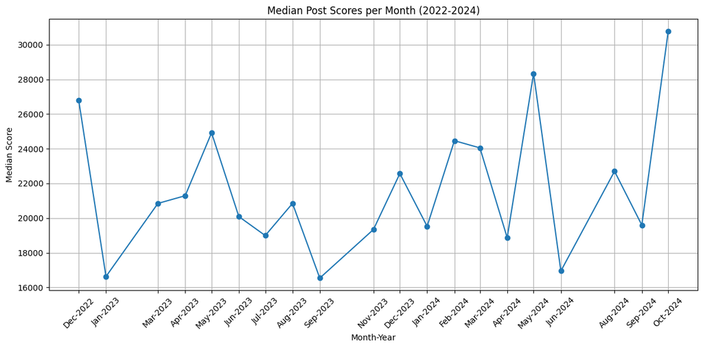

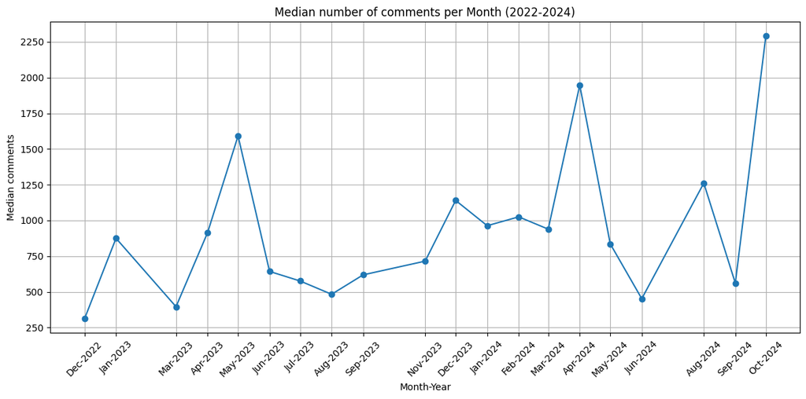

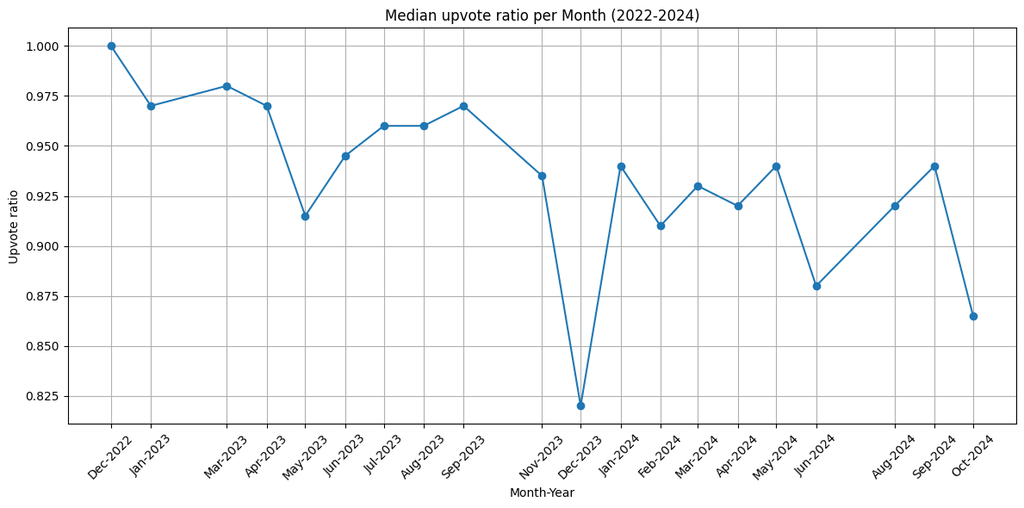

```python
# Group by 'year_month' and calculate median metrics
engagement_df = posts_df.groupby(['year_month']).agg({
    'score': 'median',
    'num_comments': 'median',
    'upvote_ratio': 'median'
}).reset_index()  # Reset the index to convert back to DataFrame

# Convert 'year_month' to timestamps for plotting
engagement_df['year_month'] = engagement_df['year_month'].dt.to_timestamp()

# Plotting
plt.figure(figsize=(12, 6))
plt.plot(engagement_df['year_month'], engagement_df['score'], marker='o')

# Formatting x-axis ticks to show "MMM-YYYY"
plt.xticks(engagement_df['year_month'], engagement_df['year_month'].dt.strftime('%b-%Y'), rotation=45)

plt.title('Median Post Scores per Month (2022-2024)')
plt.xlabel('Month-Year')
plt.ylabel('Median Score')
plt.grid()
plt.tight_layout()
plt.show()

# Plotting
plt.figure(figsize=(12, 6))
plt.plot(engagement_df['year_month'], engagement_df['num_comments'], marker='o')

# Formatting x-axis ticks to show "MMM-YYYY"
plt.xticks(engagement_df['year_month'], engagement_df['year_month'].dt.strftime('%b-%Y'), rotation=45)

plt.title('Median number of comments per Month (2022-2024)')
plt.xlabel('Month-Year')
plt.ylabel('Median comments')
plt.grid()
plt.tight_layout()
plt.show()

# Plotting
plt.figure(figsize=(12, 6))
plt.plot(engagement_df['year_month'], engagement_df['upvote_ratio'], marker='o')

# Formatting x-axis ticks to show "MMM-YYYY"
plt.xticks(engagement_df['year_month'], engagement_df['year_month'].dt.strftime('%b-%Y'), rotation=45)

plt.title('Median upvote ratio per Month (2022-2024)')
plt.xlabel('Month-Year')
plt.ylabel('Upvote ratio')
plt.grid()
plt.tight_layout()
plt.show()
```

##### **Extracting comments from each post**

```python
# Get comments on all posts
comments_list =[]
for post_id in posts_df['post_id']:
    submission = reddit.submission(post_id)
    submission.comments.replace_more(limit=10)
    for comment in submission.comments.list():
        comments_list.append({'post_id':post_id,
                              'comment':comment.body})

# Creating a dataframe
comments_df=pd.DataFrame(comments_list)
comments_df.to_csv('Only_ChatGPT_comments.csv',header=True,index=False)
comments_df.head(10)
```

|  | post_id | comment |
| --- | --- | --- |
| 0 | 144lfc1 | Hey /u/rich_awo, please respond to this commen... |
| 1 | 144lfc1 | I tried the exact inputs and this is what I go... |
| 2 | 144lfc1 | Broseph Stalin has me dead hahahaha. |
| 3 | 144lfc1 | I’ve had similar conversation with ChatGPT and... |
| 4 | 144lfc1 | Does anyone talk bro on this plane?\n\n![gif](... |
| 5 | 144lfc1 | Bro hard or bro home |
| 6 | 144lfc1 | I tried this but I asked it about the chemical... |
| 7 | 144lfc1 | Nahh chatgpt is 🔥🔥🔥🔥🤣🤣 |
| 8 | 144lfc1 | That last one is Steven Colbert trying to soun... |
| 9 | 144lfc1 | When the machines finally come for us they'll ... |

```python
comments_df.shape
```

```
(81529, 2)
```

```python
#Merge posts with their comments so that we know which comments belong to which post
comments_post_df= posts_df.merge(comments_df, on= 'post_id', how='left')
```

```python
comments_post_df['comment'].isnull().sum()
```

```
0
```

```python
#Remove rows with missing comments
comments_post_df= comments_post_df[~comments_post_df['comment'].isnull()]
```

```python
comments_post_df.shape
```

```
(81529, 11)
```

```python
comments_post_df.to_csv('ChatGPT_comments_post.csv',header=True,index=False)
```

#### **3. WORD CLOUDS**

##### **Generating word clouds to identify the most frequently used words**

Post title word cloud

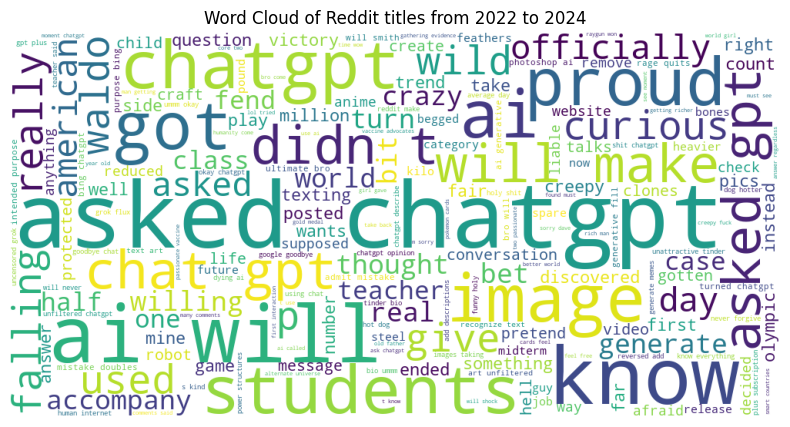

```python
post_title_text = ' '.join([title for title in posts_df['post_title'].str.lower()]
                          )
word_cloud = WordCloud(collocation_threshold=2,
                       width=1000,
                       height=500,
                       background_color='white').generate(post_title_text)

# Display the generated word cloud
plt.figure(figsize=(10,5))
plt.imshow(word_cloud)
plt.title('Word Cloud of Reddit titles from 2022 to 2024')
plt.axis("off")
plt.show()
```

Comment word cloud

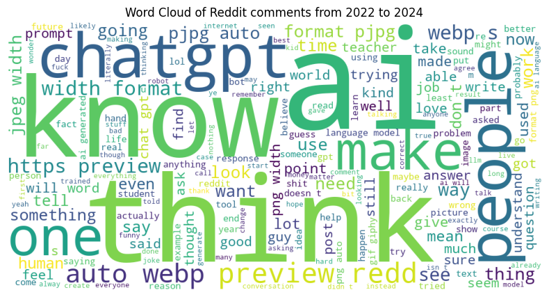

```python
post_comment_text = ' '.join([comment for comment in comments_df['comment'].str.lower()]
                          )
word_cloud = WordCloud(collocation_threshold=2,
                       width=1000,
                       height=500,
                       background_color='white').generate(post_comment_text)

# Display the generated word cloud
plt.figure(figsize=(10,5))
plt.imshow(word_cloud)
plt.title('Word Cloud of Reddit comments from 2022 to 2024')
plt.axis("off")
plt.show()
```

Post title word cloud segmented by year

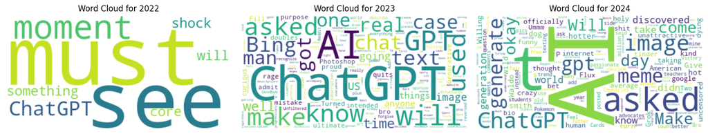

```python
# Create a function to generate word clouds
def generate_wordcloud(year):
    # Filter posts for the specified year
    text = " ".join(posts_df[posts_df['created_year'] == year]['post_title'])

    # Generate the word cloud
    return WordCloud(width=400, height=200, background_color='white').generate(text)

# Create a figure for subplots
plt.figure(figsize=(15, 5))

# Get unique years from the DataFrame
unique_years = sorted(posts_df['created_year'].unique())

# Generate word clouds for each year and plot them
for i, year in enumerate(unique_years, start=1):
    plt.subplot(1, len(unique_years), i)  # Adjust number of columns based on unique years
    wordcloud = generate_wordcloud(year)
    plt.imshow(wordcloud, interpolation='bilinear')
    plt.axis('off')  # Turn off axis
    plt.title(f'Word Cloud for {year}')

# Adjust layout
plt.tight_layout()
plt.show()
```

### **4. Sentiment Analysis**:

#### **Testing sentiment analysis models**

```python
sentiment_classifier("I Love you")
```

```
[{'label': 'POS', 'score': 0.9918103814125061}]
```

The score from the sentiment classifier typically ranges from 0 to 1. It represents the model's confidence in its prediction. A score closer to 1 indicates high confidence in the assigned label, while a score closer to 0 suggests lower confidence. In our example, a score of approximately 0.99 indicates strong confidence that the sentiment is positive (labeled as 'POS')

```python
sentiment_classifier("who are you?")
```

```
[{'label': 'NEU', 'score': 0.9472994804382324}]
```

```python
sentiment_classifier("How do I prompt for images like this in chatgpt? I can in midjorney, but the gpt never gives me realistic images")
```

```
[{'label': 'NEG', 'score': 0.6928576827049255}]
```

```python
sentiment_classifier("What app you're using to access ChatGPT?")
```

```
[{'label': 'NEU', 'score': 0.9642482995986938}]
```

```python
sentiment_classifier('Bing fucks, chatGPT is greatest ever')
```

```
[{'label': 'NEG', 'score': 0.954913318157196}]
```

We can observe that the sentiment analysis is performing decently well. However, it struggles with comments that are phrased as questions or contain mixed sentiments (both negative and positive) within a single sentence. Therefore, we should be mindful of its accuracy in these cases.

Let us define a function to get sentiment

```python
def get_sentiment(text):
    # Truncate the input text to the model's maximum length
    text = text[:128]  # Keep only the first 128 characters
    # Get sentiment prediction scores
    try:
        sentiment = sentiment_classifier(text)[0]['label']
    except Exception as e:
        sentiment = 'Not classified'
    return sentiment
```

```python
posts_df['post_sentiment'] = posts_df['post_title'].astype(str).apply(lambda x: get_sentiment(x))
posts_df.head(3)
```

|  | post_id | subreddit | created_date | selftext | post_url | post_title | link_flair_text | score | num_comments | upvote_ratio | created_year | year_month | post_sentiment |
| --- | --- | --- | --- | --- | --- | --- | --- | --- | --- | --- | --- | --- | --- |
| 0 | 144lfc1 | ChatGPT | 2023-06-09 02:46:59 |  | https://i.redd.it/81rl4zdt1v4b1.png | Turned ChatGPT into the ultimate bro | Funny | 67512 | 1147 | 0.96 | 2023 | 2023-06 | POS |
| 1 | 1av10qh | ChatGPT | 2024-02-20 04:07:20 |  | https://v.redd.it/td4k2r8idmjc1 | Will smith is wild for this | Funny | 56180 | 1706 | 0.86 | 2024 | 2024-02 | POS |
| 2 | 13wfaqg | ChatGPT | 2023-05-31 12:55:04 |  | https://www.reddit.com/gallery/13wfaqg | Photoshop AI Generative Fill was used for its ... | Other | 52080 | 1342 | 0.91 | 2023 | 2023-05 | NEU |

#### **Visualizing sentiment distribution for posts and comments using pie charts**

Distribution of `post_title` sentiments

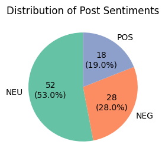

```python
post_sentiment_counts = posts_df['post_sentiment'].value_counts()

plt.figure(figsize=(4, 3))

# Function to format the label with count and percentage
def func(pct, allvalues):
    absolute = int(pct / 100. * sum(allvalues))
    return f"{absolute}\n({pct:.1f}%)"

# Plotting the pie chart
wedges, texts, autotexts = plt.pie(
    post_sentiment_counts,
    labels=post_sentiment_counts.index,
    autopct=lambda pct: func(pct, post_sentiment_counts),
    startangle=90,
    colors=['#66c2a5', '#fc8d62', '#8da0cb']
)

plt.title('Distribution of Post Sentiments')
plt.show()
```

```python
comments_post_df.shape
```

```
(81529, 11)
```

We have 81,529 rows in the DataFrame. Given that the sentiment classifier model will take considerable time to process the entire dataset, and not all comments are directly related to ChatGPT, we will take a subset of this data for further analysis.

```python
# Lets extract the entries where the comments contain contain ChatGPT word
comments_post_df_sub = comments_post_df[comments_post_df['comment'].str.contains('chatgpt', case=False)]
z=comments_post_df_sub[comments_post_df_sub['comment'].str.len()<=128].reset_index()
z.shape
```

```
(2139, 12)
```

```python
z[['post_title','selftext','comment']].to_csv('ChatGPT_in_comments_128_2139.csv')
z[['post_title','selftext','comment']].head(10)
```

|  | post_title | selftext | comment |
| --- | --- | --- | --- |
| 0 | Turned ChatGPT into the ultimate bro | NaN | Nahh chatgpt is 🔥🔥🔥🔥🤣🤣 |
| 1 | Turned ChatGPT into the ultimate bro | NaN | How does ChatGPT have an escalating ranking an... |
| 2 | Turned ChatGPT into the ultimate bro | NaN | What app you're using to access ChatGPT? |
| 3 | Turned ChatGPT into the ultimate bro | NaN | Does Chatgpt have a mobile app yet? Can you te... |
| 4 | Turned ChatGPT into the ultimate bro | NaN | Is this ChatGPT-4? |
| 5 | Turned ChatGPT into the ultimate bro | NaN | Oh man, this had me laughing! Not too shabby C... |
| 6 | Turned ChatGPT into the ultimate bro | NaN | I feel like I’ve seen this posted ten times, I... |
| 7 | Turned ChatGPT into the ultimate bro | NaN | ChadGPT > ChatGPT |
| 8 | Turned ChatGPT into the ultimate bro | NaN | Nothing tops Brosephus Maxima, though. ChatGPT... |
| 9 | Turned ChatGPT into the ultimate bro | NaN | Oh my god, ChatGPT understands humour.\n\nThe ... |

```python
# Get sentiment of all comments which contains chatgpt word
z['comment_sentiment'] = z['comment'].astype(str).apply(lambda x: get_sentiment(x))

comment_contain_chatgpt_df = z
comment_contain_chatgpt_df.head(10)
```

|  | index | post_id | subreddit | created_utc | selftext | post_url | post_title | link_flair_text | score | num_comments | upvote_ratio | comment | comment_sentiment |
| --- | --- | --- | --- | --- | --- | --- | --- | --- | --- | --- | --- | --- | --- |
| 0 | 7 | 144lfc1 | ChatGPT | 1.686259e+09 | NaN | https://i.redd.it/81rl4zdt1v4b1.png | Turned ChatGPT into the ultimate bro | Funny | 67521 | 1147 | 0.96 | Nahh chatgpt is 🔥🔥🔥🔥🤣🤣 | NEU |
| 1 | 13 | 144lfc1 | ChatGPT | 1.686259e+09 | NaN | https://i.redd.it/81rl4zdt1v4b1.png | Turned ChatGPT into the ultimate bro | Funny | 67521 | 1147 | 0.96 | How does ChatGPT have an escalating ranking an... | NEU |
| 2 | 26 | 144lfc1 | ChatGPT | 1.686259e+09 | NaN | https://i.redd.it/81rl4zdt1v4b1.png | Turned ChatGPT into the ultimate bro | Funny | 67521 | 1147 | 0.96 | What app you're using to access ChatGPT? | NEU |
| 3 | 61 | 144lfc1 | ChatGPT | 1.686259e+09 | NaN | https://i.redd.it/81rl4zdt1v4b1.png | Turned ChatGPT into the ultimate bro | Funny | 67521 | 1147 | 0.96 | Does Chatgpt have a mobile app yet? Can you te... | NEU |
| 4 | 81 | 144lfc1 | ChatGPT | 1.686259e+09 | NaN | https://i.redd.it/81rl4zdt1v4b1.png | Turned ChatGPT into the ultimate bro | Funny | 67521 | 1147 | 0.96 | Is this ChatGPT-4? | NEU |
| 5 | 95 | 144lfc1 | ChatGPT | 1.686259e+09 | NaN | https://i.redd.it/81rl4zdt1v4b1.png | Turned ChatGPT into the ultimate bro | Funny | 67521 | 1147 | 0.96 | Oh man, this had me laughing! Not too shabby C... | POS |
| 6 | 104 | 144lfc1 | ChatGPT | 1.686259e+09 | NaN | https://i.redd.it/81rl4zdt1v4b1.png | Turned ChatGPT into the ultimate bro | Funny | 67521 | 1147 | 0.96 | I feel like I’ve seen this posted ten times, I... | NEG |
| 7 | 109 | 144lfc1 | ChatGPT | 1.686259e+09 | NaN | https://i.redd.it/81rl4zdt1v4b1.png | Turned ChatGPT into the ultimate bro | Funny | 67521 | 1147 | 0.96 | ChadGPT > ChatGPT | NEU |
| 8 | 110 | 144lfc1 | ChatGPT | 1.686259e+09 | NaN | https://i.redd.it/81rl4zdt1v4b1.png | Turned ChatGPT into the ultimate bro | Funny | 67521 | 1147 | 0.96 | Nothing tops Brosephus Maxima, though. ChatGPT... | POS |
| 9 | 115 | 144lfc1 | ChatGPT | 1.686259e+09 | NaN | https://i.redd.it/81rl4zdt1v4b1.png | Turned ChatGPT into the ultimate bro | Funny | 67521 | 1147 | 0.96 | Oh my god, ChatGPT understands humour.\n\nThe ... | POS |

Distribution of `comment` sentiments

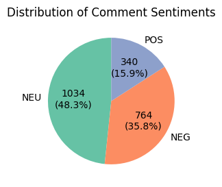

```python
sentiment_counts = comment_contain_chatgpt_df['comment_sentiment'].value_counts()

plt.figure(figsize=(4, 3))

# Function to format the label with count and percentage
def func(pct, allvalues):
    absolute = int(pct / 100. * sum(allvalues))
    return f"{absolute}\n({pct:.1f}%)"

# Plotting the pie chart
wedges, texts, autotexts = plt.pie(
    sentiment_counts,
    labels=sentiment_counts.index,
    autopct=lambda pct: func(pct, sentiment_counts),
    startangle=90,
    colors=['#66c2a5', '#fc8d62', '#8da0cb']
)

plt.title('Distribution of Comment Sentiments')
plt.show()
```

#### **Word cloud of common words categorized by sentiment (Positive, Negative, Neutral)**

Let's explore which words are most commonly repeated across Positive, Negative, and Neutral sentiment comments by generating word clouds for each sentiment category.

```python
# Create a function to generate word clouds for each sentiment
def generate_wordclouds(df):
    sentiments = df['comment_sentiment'].unique()  # Get unique sentiments

    plt.figure(figsize=(15, 10))

    for i, sentiment in enumerate(sentiments):
        # Filter comments by sentiment
        comments = df[df['comment_sentiment'] == sentiment]['comment']
        text = ' '.join(comments)  # Combine comments into a single string

        # Generate word cloud
        wordcloud = WordCloud(width=800, height=400, background_color='white').generate(text)

        # Plot the word cloud
        plt.subplot(1, len(sentiments), i + 1)
        plt.imshow(wordcloud, interpolation='bilinear')
        plt.axis('off')  # Turn off axis
        plt.title(f'Word Cloud for {sentiment} Sentiment')

    plt.tight_layout()
    plt.show()
```

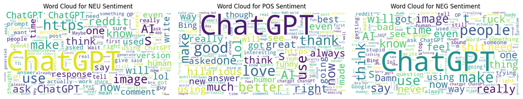

```python
# Create Wordcloud
generate_wordclouds(comment_contain_chatgpt_df)
```

It is evident that "ChatGPT" appears as the most common word across all sentiment categories. This is expected since we filtered our dataset to include comments containing the word "ChatGPT."

In the positive sentiment word cloud, we can observe words such as "love," "great," "good," and "thank," indicating the favorable sentiments expressed by users.

### **5. Engagement Analysis**

#### **Analyzing engagement metrics by `link_flair_text`.**

```python
# Group by link_flair_text and calculate average metrics
flair_performance = posts_df.groupby(['link_flair_text']).agg({
    'score': 'median',
    'num_comments': 'median',
    'upvote_ratio': 'median'
})

# Change index name
flair_performance.index.name = 'link flair text'

# Rename the columns
flair_performance = flair_performance.rename(columns={
    'score': 'median score',
    'num_comments': 'median no. of comments',
    'upvote_ratio': 'median upvote ratio'
})

flair_performance.sort_values(by='median score',ascending=False).reset_index()
```

|  | link flair text | median score | median no. of comments | median upvote ratio |
| --- | --- | --- | --- | --- |
| 0 | Mona Lisa: Multiverse of Madness:illuminati: | 29453.0 | 1822.0 | 0.830 |
| 1 | Fake | 25472.0 | 657.0 | 0.950 |
| 2 | Jailbreak | 22555.5 | 536.0 | 0.930 |
| 3 | Gone Wild | 22551.5 | 1258.0 | 0.945 |
| 4 | AI-Art | 22089.0 | 1455.0 | 0.900 |
| 5 | Funny | 21983.0 | 717.0 | 0.950 |
| 6 | Serious replies only :closed-ai: | 21752.0 | 2851.0 | 0.905 |
| 7 | Prompt engineering | 20847.0 | 1274.0 | 0.940 |
| 8 | Other | 19982.0 | 1349.0 | 0.910 |
| 9 | News 📰 | 19528.0 | 906.0 | 0.950 |
| 10 | Funny | 18960.5 | 709.5 | 0.975 |
| 11 | The right way | 18720.0 | 884.0 | 0.940 |
| 12 | Use cases | 17592.0 | 668.0 | 0.850 |
| 13 | Educational Purpose Only | 17000.5 | 1135.5 | 0.900 |

#### **Evaluating engagement based on post sentiment**

```python
# Group by post_sentiment and calculate average metrics
post_sentiment_performance = posts_df.groupby(['post_sentiment']).agg({
    'score': 'median',
    'num_comments': 'median',
    'upvote_ratio': 'median'
})

# Change index name
post_sentiment_performance.index.name = 'Post Sentiment'

# Rename the columns
post_sentiment_performance = post_sentiment_performance.rename(columns={
    'score': 'median score',
    'num_comments': 'median no. of comments',
    'upvote_ratio': 'median upvote ratio'
})

post_sentiment_performance.sort_values(by='median score',ascending=False).reset_index()
```

|  | Post Sentiment | median score | median no. of comments | median upvote ratio |
| --- | --- | --- | --- | --- |
| 0 | POS | 24368.5 | 638.0 | 0.95 |
| 1 | NEG | 21516.0 | 1054.0 | 0.94 |
| 2 | NEU | 19564.0 | 879.5 | 0.94 |

We can observe that Negative posts tend to receive a higher number of comments, indicating more engagement from users. In contrast, Positive posts have the highest upvote ratio and overall score, suggesting that users find them more favorable and engaging.

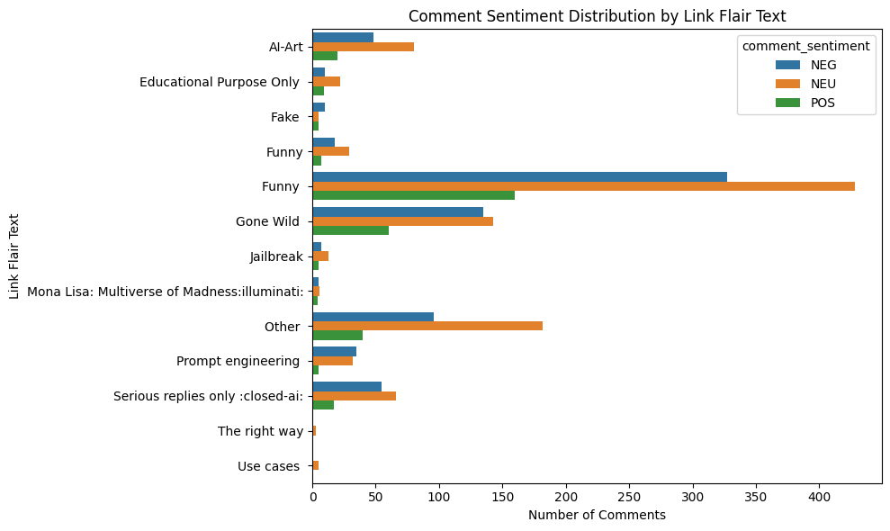

```python
grouped_df = comment_contain_chatgpt_df.groupby(['link_flair_text', 'comment_sentiment'])['post_id'].count().reset_index()

# Create a horizontal bar plot with Seaborn
plt.figure(figsize=(10, 6))
sns.barplot(data=grouped_df, y='link_flair_text', x='post_id', hue='comment_sentiment', orient='h')

plt.title('Comment Sentiment Distribution by Link Flair Text')
plt.xlabel('Number of Comments')
plt.ylabel('Link Flair Text')
plt.tight_layout()
plt.show()
```